# ¿Podemos confiar en el tiempo promedio de espera de los pacientes?

Autores/as

André Rosero

Alejandro Navarrete

Fecha de publicación

18 de noviembre de 2026

# 1 Resumen ejecutivo

Se analizaron 1239 atenciones con especialidad registrada y tiempo de espera válido.  
La mediana fue de 31 minutos, con un intervalo bootstrap del 90 % de 29.3 a 32.5 minutos; la media fue de 43.7 minutos.  
Se recomienda la mediana para describir la espera habitual, acompañada de información sobre las demoras extremas.  
La selección exclusiva de encuestados sobreestima la espera media; los resultados se limitan a los registros sintéticos analizados.

# 2 Datos, variables y decisiones de limpieza

Los datos proceden del archivo sintético `atenciones_raw.csv`. La variable principal es el tiempo entre el registro y el inicio de la consulta, expresado en minutos. El código de importación y limpieza está en `preprocesar.R`; aquí se presentan sus resultados y las decisiones tomadas.

## 2.1 Variables

Se utilizó `read.csv2()` porque el archivo está separado por punto y coma. Se interpretaron como faltantes `NA`, `N/A`, guion y campos vacíos. Se revisaron las primeras filas, los tipos de datos y el resumen de cada columna.

Tabla 1: Variables y escalas de medición

| variable | tipo | escala | tipo_en_R |
| --- | --- | --- | --- |
| id_atencion | Identificador | Nominal | character |
| fecha | Fecha | Intervalo | character |
| especialidad | Categórica | Nominal | character |
| turno | Categórica | Nominal | character |
| tipo_paciente | Categórica | Nominal | character |
| tiempo_espera | Continua | Razón | character |
| respondio_encuesta | Categórica | Nominal | character |
| satisfaccion | Ordinal | Ordinal | character |

La Tabla 1 distingue la escala de medición del tipo que asignó R. Las fechas y los tiempos se importaron como texto y necesitan conversión. La satisfacción se trata como ordinal porque sus niveles tienen un orden.

## 2.2 Decisiones de limpieza

Se eliminaron duplicados exactos y se unificaron mayúsculas y espacios en las categorías. Los tiempos en horas se multiplicaron por 60; los valores sin unidad se interpretaron como minutos.

Se aplicó la conversión de la guía, que elimina símbolos y letras antes de convertir a número. En este archivo también elimina `$`: se asume que es un error de escritura en la columna de espera. Esta decisión debe comprobarse con quien entregó los datos. Los textos sin un número se convierten en faltantes.

También se unificaron las variantes con y sin tilde de las especialidades y los turnos. Por ejemplo, “cardiologia” y “cardiología” se registraron como una misma especialidad. Después de la corrección quedaron cuatro especialidades y tres turnos.

En la variable satisfacción se quitaron los espacios antes de convertirla en un factor ordenado del 1 al 5. Esto permitió conservar respuestas válidas como “ 4 ”. Los valores fuera de esa escala (0 y 6) y el texto “sin respuesta” se trataron como faltantes. Estas atenciones se mantienen en el análisis del tiempo de espera cuando cumplen sus criterios de inclusión.

Tabla 2: Problemas encontrados y decisiones

| problema | cantidad | decision |
| --- | --- | --- |
| Duplicados exactos | 11 | Eliminar copias exactas |
| Repeticiones de identificador | 6 | Conservar: las filas no son idénticas |
| Tiempos en horas | 102 | Multiplicar por 60 |
| Tiempos faltantes o no numéricos | 24 | Excluir del análisis de espera |
| Tiempos negativos | 11 | Excluir del análisis de espera |
| Fechas no convertidas | 10 | Conservar como fecha faltante |
| Satisfacción válida con espacios | 212 | Quitar espacios antes de convertir a factor |
| Satisfacción fuera de escala | 6 | Tratar 0 y 6 como faltantes |
| Satisfacción: texto sin respuesta | 1 | Tratar sin respuesta como faltante |

La Tabla 2 registra los principales problemas. Se conservan los identificadores repetidos porque sus filas tienen datos diferentes y no hay información suficiente para elegir cuál eliminar. Pueden afectar los resultados si representan la misma atención.

Tabla 3: Cantidad de filas por etapa

| etapa | cantidad |
| --- | --- |
| Original | 1285 |
| Sin duplicados exactos | 1274 |
| Base analítica | 1239 |

La base depurada se guardó en `data/processed/atenciones.csv` antes de seleccionar las filas para el análisis. La Tabla 3 muestra cuántas quedan en cada etapa.

# 3 Descripción de la variable principal

Siguiendo el ejemplo de la guía, se incluyen las atenciones con especialidad registrada y espera observada no negativa. Se admite cero porque puede representar atención inmediata. Esta selección podría introducir sesgo si los datos faltantes se relacionan con la espera.

Tabla 4: Medidas descriptivas de la espera en minutos

| medida | valor |
| --- | --- |
| media | 43.70 |
| mediana | 31.00 |
| sd | 52.95 |
| IQR | 37.20 |
| minimo | 0.00 |
| maximo | 540.10 |

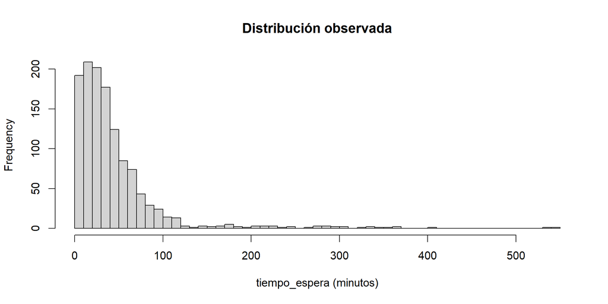

Figura 1: Distribución de la variable principal

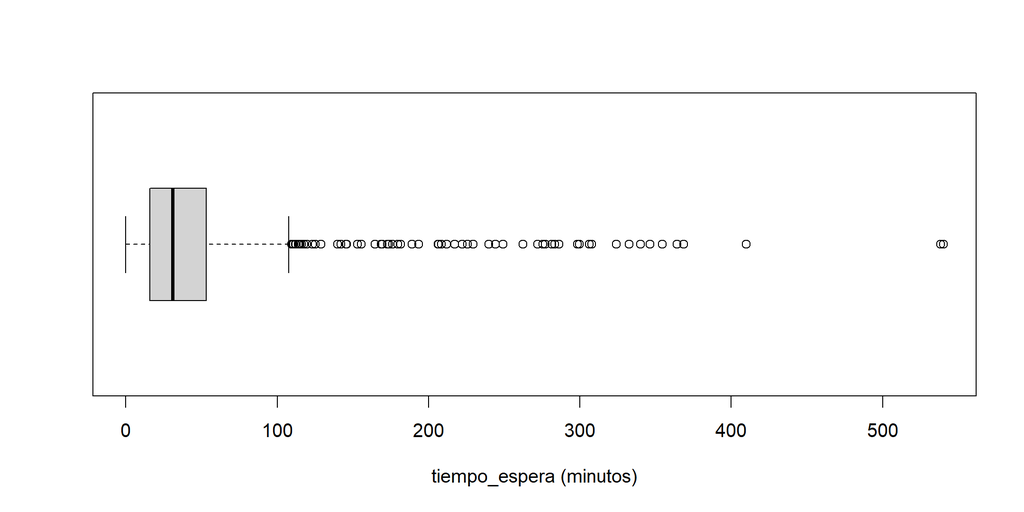

Figura 2: Diagrama de caja de la variable principal

La media es **43.7 minutos** y la mediana es **31 minutos** (Tabla 4). La media es mayor que la mediana porque las esperas largas la elevan. La Figura 1 muestra una cola hacia la derecha.

Hay **67 esperas** por encima del límite superior de la caja, de 108.95 minutos (Figura 2). Son valores para revisar, no errores confirmados; por eso se conservaron.

La mediana describe mejor la espera habitual porque resulta menos afectada por valores muy altos. Sin embargo, una sola cifra no muestra las diferencias entre pacientes ni las demoras extremas. Los intervalos de confianza se presentan en la sección correspondiente.

# 4 Muestreo, selección y sesgo

Se utiliza como población de referencia el conjunto de atenciones con especialidad registrada y tiempo de espera válido. Se comparan tres procedimientos: muestreo aleatorio simple, selección entre quienes respondieron la encuesta y muestreo estratificado por especialidad. Para cada procedimiento se obtienen 500 muestras de 100 atenciones y se calcula la media de cada muestra.

Cada procedimiento se repite 500 veces. En cada repetición se seleccionan 100 atenciones y se calcula su tiempo medio de espera. Por tanto, cada histograma de la Figura 3 resume 500 medias muestrales, cada una calculada con 100 atenciones.

El eje horizontal muestra las medias de espera en minutos. El eje vertical indica cuántas muestras produjeron una media dentro de cada intervalo. Las barras representan frecuencias de medias muestrales. La línea vertical discontinua señala, en los tres gráficos, la media de las 1.239 atenciones de referencia. Comparar las barras con esta línea permite observar si un procedimiento tiende a producir medias superiores o inferiores a la referencia.

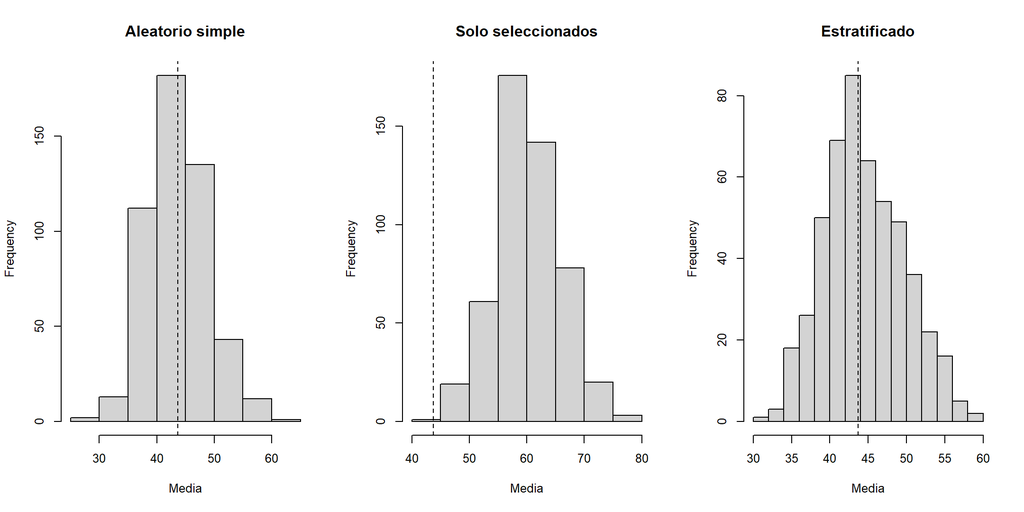

Figura 3: Comparación de medias por procedimiento de muestreo

La Figura 3 muestra que las medias del muestreo aleatorio simple se distribuyen alrededor de la media de referencia. Las diferencias entre sus muestras reflejan variación por azar. En cambio, las medias obtenidas únicamente de quienes respondieron la encuesta se desplazan hacia valores superiores. Por tanto, utilizar solo a los encuestados sobreestima la espera media de la población de referencia y evidencia un sesgo de selección en este análisis.

El muestreo estratificado produce medias cercanas a la referencia, pero asignar 25 atenciones a cada especialidad les da un peso del 25 % en la muestra, lo que no respeta sus proporciones en la población de referencia. Por ello, esta asignación no garantiza reproducir la media global. La comparación tampoco permite establecer por qué los pacientes decidieron responder la encuesta.

# 5 TLC, error estándar y cobertura

La distribución de los tiempos individuales se compara con las distribuciones de medias obtenidas de muestras de distintos tamaños. Para cada tamaño se generan 1.000 muestras y se calcula la media de cada una. El objetivo es observar cómo cambian la forma y la dispersión de las medias al aumentar la muestra.

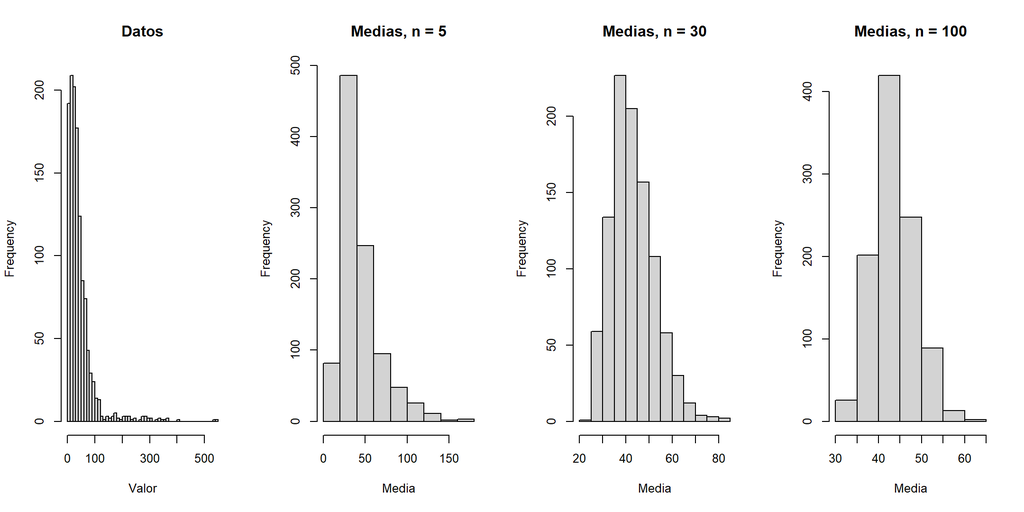

Figura 4: Tiempos individuales y medias de muestras de distintos tamaños

En la Figura 4, el primer panel muestra tiempos individuales. Los otros tres muestran medias muestrales: cada media se calcula con 5, 30 o 100 atenciones, respectivamente. Los ejes horizontales tienen escalas distintas, lo que debe considerarse al comparar la dispersión.

La desviación estándar describe la variación entre tiempos individuales. El error estándar describe la variación de la media entre muestras del mismo tamaño. Su estimación habitual es:

$$SE(\bar X) = \frac{s}{\sqrt{n}}$$

Para muestras de 50 atenciones se compara esta fórmula con la desviación estándar de 2.000 medias simuladas.

| SE Fórmula | SE Empírico |
| --- | --- |
| 7.487979 | 7.429226 |

La Figura 4 muestra una marcada asimetría positiva en los tiempos individuales. Al aumentar el tamaño de muestra de 5 a 30 y 100 atenciones, la distribución de las medias se vuelve más cercana a una distribución normal y presenta menor dispersión. Este comportamiento ilustra el teorema del límite central.

Para muestras de 50 atenciones, el error estándar calculado con la fórmula es de 7.49 minutos y el empírico es de 7.43 minutos. Ambos son aproximadamente similares. Las diferencias se relacionan con la variación de la simulación y con que el muestreo se realiza sin reemplazo desde una población finita.

La desviación estándar describe la variabilidad de los tiempos individuales; el error estándar describe cuánto varía la media entre muestras del mismo tamaño. Según la aproximación SE = s / sqrt(n), cuadruplicar el tamaño muestral reduce el error estándar a la mitad. Esto mejora la precisión de la media estimada, aunque no corrige un posible sesgo de selección.

# 6 Intervalos bootstrap y clásico, con interpretación

Se selecciona una muestra aleatoria de 40 atenciones de la población de referencia. A partir de ella se generan 2.000 remuestras bootstrap, cada una de 40 observaciones tomadas con reemplazo. Se calcula la media de cada remuestra y se utilizan sus percentiles 5 y 95 para construir un intervalo bootstrap del 90 %. Este resultado se compara con el intervalo clásico basado en la distribución t, calculado sobre la misma muestra inicial.

```
[1] 40.273
```

```
      5%      95%
28.82225 54.52420
```

```
[1] 27.06542 53.48058
attr(,"conf.level")
[1] 0.9
```

El intervalo bootstrap del 90 % para la media va de 28.82 a 54.52 minutos; el intervalo t va de 27.07 a 53.48 minutos. El nivel de confianza del 90 % se refiere al procedimiento: al repetir el muestreo y la construcción de intervalos, se espera que aproximadamente el 90 % contenga la media fija de referencia. No significa que exista una probabilidad del 90 % de que esa media esté dentro de este intervalo ya calculado. En general, aumentar el tamaño de muestra reduce la anchura del intervalo, mientras que exigir un 99 % de confianza la aumenta.

Se evalúa la cobertura del intervalo t del 90 % mediante 1.000 repeticiones para cada tamaño muestral. En cada repetición se comprueba si el intervalo contiene la media de referencia.

Tabla 5: Cobertura simulada del intervalo t del 90 %

| n | cobertura_porcentaje |
| --- | --- |
| 10 | 79.9 |
| 30 | 81.1 |
| 100 | 86.3 |

La Tabla 5 muestra que, en esta simulación, la cobertura aumenta con el tamaño muestral. Para n = 10 y n = 30 se obtienen coberturas inferiores al 90 % nominal, mientras que para n = 100 el resultado se aproxima a ese nivel.

La fuerte asimetría de los tiempos dificulta el funcionamiento del intervalo t con muestras pequeñas. Estos resultados muestran que una confianza nominal del 90 % no garantiza una cobertura observada exactamente igual al 90 %, y que una muestra de 30 observaciones no siempre es suficiente para obtener una buena aproximación.

## 6.1 Intervalo para la mediana de espera

Para acompañar la descripción de la espera habitual, se calcula un intervalo bootstrap del 90 % para la mediana. Se utilizan todos los tiempos válidos disponibles como muestra y se generan 2.000 remuestras con reemplazo, cada una del mismo tamaño que el conjunto analizado. Este procedimiento supone observaciones independientes y no corrige posibles sesgos de selección.

```
[1] 31
```

```
  5%  95%
29.3 32.5
```

La mediana observada es de 31 minutos, con un intervalo bootstrap del 90 % entre 29.3 y 32.5 minutos. Este intervalo describe la incertidumbre de la mediana estimada; no significa que el 90 % de los pacientes espere dentro de ese rango.

# 7 Conclusiones y recomendación para la persona responsable

Se recomienda utilizar la mediana de 31 minutos como indicador principal de la espera habitual, acompañada de su intervalo bootstrap del 90 %, de 29.3 a 32.5 minutos. La mediana resulta menos afectada por las esperas extraordinariamente largas que la media de 43.7 minutos.

Para planificación, conviene presentar también la media y revisar las demoras extremas, pues una sola cifra no resume todas las experiencias. La mediana describe la situación observada; convertirla en una meta operativa requiere considerar la capacidad del centro y las diferencias entre especialidades y turnos.

El análisis mostró que utilizar únicamente las respuestas de la encuesta sobreestima la espera media del conjunto de referencia. Por ello, se recomienda calcular los indicadores con todas las atenciones válidas disponibles.

Los resultados corresponden a un archivo sintético y están condicionados por las decisiones de limpieza, los registros excluidos y los identificadores repetidos conservados. El intervalo bootstrap supone observaciones independientes y no corrige sesgos de selección; por tanto, no permite generalizar automáticamente a todos los pacientes reales de un centro médico.